# Initiation à R

### Génération d'aléa - tirage gaussien [rnorm]

```r
set.seed(123) # permet de reproduire les mêmes résultats d'une fois sur l'autre en dépit de l'aléa présent
n <- 50
Y <- rnorm(n,20,5)

mean(Y) # moyenne empirique
```

```
[1] 20.17202
```

```r
sd(Y) # écart-type empirique
```

```
[1] 4.62935
```

```r
sd(Y)/sqrt(length(Y)) # écart-type de la moyenne empirique
```

```
[1] 0.6546889
```

```r
summary(Y) # quartiles et moyenne empiriques
```

```
   Min. 1st Qu.  Median    Mean 3rd Qu.    Max.
  10.17   17.20   19.64   20.17   23.49   30.84
```

### Génération d'aléa - visualisation du tirage [boxplot]

On peut représenter graphiquement cette variable

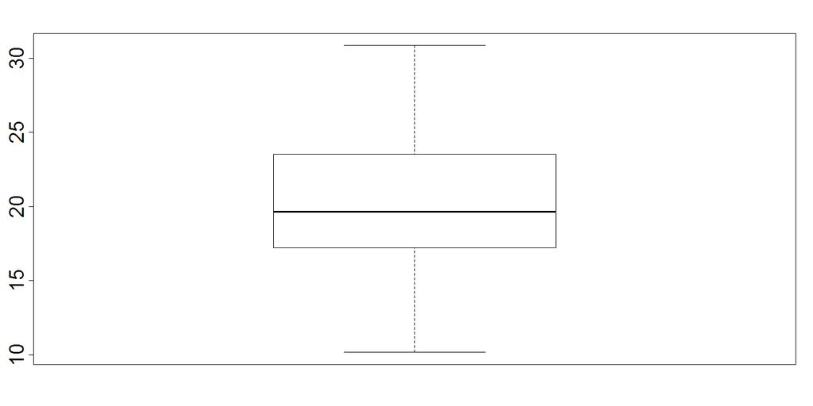

```r
boxplot(Y,cex.lab=3, cex.axis=3, cex.main=3, cex.sub=3,cex=3) # diagramme boîte
```

### Génération d'aléa - visualisation du tirage [hist & lines & curves]

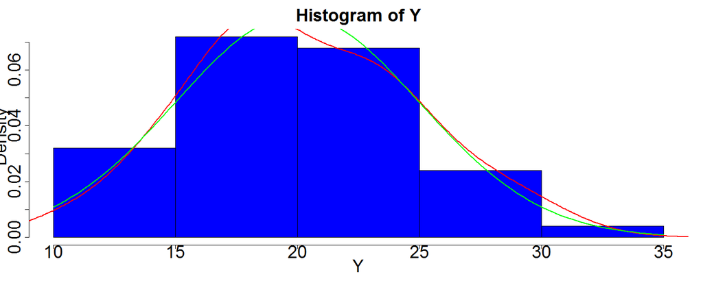

```r
hist(Y, probability=T, col="blue",cex.lab=3, cex.axis=3, cex.main=3, cex.sub=3,cex=3) # histogramme de la densité
lines(density(Y), col="red", lwd=2) # lissage de l'histogramme
# tracer la loi théorique
x <- 1:100
curve(dnorm(x,mean=20,sd=5),add=TRUE,col="green",lwd=2) # l'argument add permet de rajouter cette courbe sur le même graphique, il s'agit de la distribution théorique
```

### Génération d'aléa - tirage uniforme [runif]

On peut générer des observations tirées dans une loi uniforme sur [a,b]

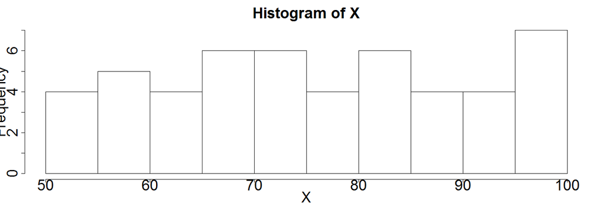

```r
X <- runif(n,50,100)
hist(X,cex.lab=3, cex.axis=3, cex.main=3, cex.sub=3,cex=3)
```

Vous pouvez augmenter la valeur de `n` pour voir ce que ça donne

## Exercice 1

### Exercice sur des données - Introduction

Pour cette entrée en matière de l'exploration d'un vrai fichier de donnée, nous nous sommes fortement inspirés de l'exercice suivant [https://www.math.univ-toulouse.fr/~besse/Wikistat/pdf/st-scenar-statlab.pdf](https://www.math.univ-toulouse.fr/%7Ebesse/Wikistat/pdf/st-scenar-statlab.pdf)

Une étude réalisée entre 1961 et 1973 dans la maternité d'un hôpital d'Oakland (Californie) avait pour but de rechercher si certaines caractéristiques des parents avaient une influence sur le développement de l'enfant. Parmi les variables collectées, 19 variables décrites dans le tableau ci-dessous ont été observées sur 115 familles ou unités statistiques. Ces variables décrivent des informations médicales et socio-économiques concernant le bébé et ses parents au moment de la naissance puis dix ans plus tard, permettant ainsi de se poser différentes questions de nature plutôt épidémiologique :

- Influence ou non de la consommation de cigarettes sur le sexe de l'enfant, sur son poids, sur sa taille,
- sur l'évolution du poids de la mère en 10 ans,
- sur les liaisons entre les caractéristiques des parents (poids, taille, rhésus) et celles de leur enfant

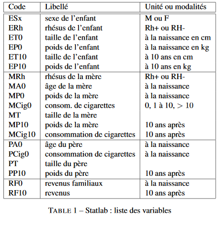

### Chargement de données [read.csv2]

```r
famil=read.csv2("statlab.csv") # lecture du fichier csv
head(famil) # aperçu du haut des données
```

```
  ESx ERh  ET0  EP0  ET10 EP10 MRh MA0  MP0   MCig0    MT MP10  MCig10 PA0
1   M  R+ 49.5 3.18 136.0 39.9  R+  18 61.0  >10cig 157.0 56.0    0cig  26
2   M  R- 48.5 2.45 124.5 23.1  R-  18 45.0  >10cig 164.5 48.5 1-10cig  22
3   M  R- 51.5 3.31 130.5 26.3  R-  20 55.0 1-10cig 157.5 60.0    0cig  21
4   M  R+ 47.0 3.40 128.5 27.2  R+  20 63.5  >10cig 166.0 65.5  >10cig  20
5   M  R+ 51.0 2.86 133.0 29.9  R+  20 46.5 1-10cig 162.5 54.5    0cig  21
6   M  R+ 51.0 2.90 137.0 33.6  R+  20 46.5  >10cig 162.0 55.0 1-10cig  22
    PCig0    PT PP10 RF0 RF10
1  >10cig 182.5 89.0  42  112
2  >10cig 178.0 66.0  37  140
3  >10cig 180.5 75.0  54  114
4  >10cig 180.5 86.0  86  180
5  >10cig 179.0 68.0  89  150
6 1-10cig 167.5 68.5  96  126
```

### Aperçu des données [summary & dim]

```r
dim(famil) # combien de colonnes et de ligne
```

```
[1] 115  19
```

```r
summary(famil) # quelques statistiques classiques
```

```
 ESx    ERh          ET0             EP0             ET10
 F:46   R-:22   Min.   :43.00   Min.   :1.770   Min.   :124.0
 M:69   R+:93   1st Qu.:51.00   1st Qu.:2.925   1st Qu.:132.5
                Median :52.00   Median :3.360   Median :136.0
                Mean   :51.93   Mean   :3.389   Mean   :136.0
                3rd Qu.:53.50   3rd Qu.:3.760   3rd Qu.:139.8
                Max.   :58.50   Max.   :6.350   Max.   :151.5
      EP10       MRh          MA0             MP0             MCig0
 Min.   :23.10   R-:19   Min.   :15.00   Min.   : 43.50   >10cig :39
 1st Qu.:27.45   R+:96   1st Qu.:24.00   1st Qu.: 51.50   0cig   :48
 Median :31.80           Median :27.00   Median : 56.50   1-10cig:28
 Mean   :32.53           Mean   :27.53   Mean   : 59.57
 3rd Qu.:36.05           3rd Qu.:32.00   3rd Qu.: 63.25
 Max.   :57.20           Max.   :43.00   Max.   :113.50
       MT             MP10            MCig10        PA0
 Min.   :148.5   Min.   : 38.50   >10cig :39   Min.   :20.00
 1st Qu.:160.2   1st Qu.: 55.25   0cig   :55   1st Qu.:26.00
 Median :164.0   Median : 61.00   1-10cig:21   Median :29.00
 Mean   :164.1   Mean   : 64.07                Mean   :30.57
 3rd Qu.:167.8   3rd Qu.: 69.25                3rd Qu.:35.00
 Max.   :178.0   Max.   :115.50                Max.   :50.00
     PCig0          PT             PP10             RF0
 >10cig :65   Min.   :158.0   Min.   : 49.50   Min.   : 14.0
 0cig   :36   1st Qu.:172.8   1st Qu.: 72.50   1st Qu.: 54.0
 1-10cig:14   Median :179.0   Median : 80.50   Median : 72.0
              Mean   :179.0   Mean   : 82.23   Mean   : 76.1
              3rd Qu.:185.5   3rd Qu.: 90.50   3rd Qu.: 93.0
              Max.   :198.0   Max.   :129.00   Max.   :250.0
      RF10
 Min.   : 21.0
 1st Qu.:110.0
 Median :150.0
 Mean   :156.5
 3rd Qu.:190.0
 Max.   :500.0
```

La fonction `summary` fournit déjà beaucoup d'information sur chaque variable. Mais on pourrait réappliquer les fonctions moyenne, écart-type, quantiles, diagramme boîte, histogramme, indépendamment, sur toutes les variables ou certaines en particulier.

### Aperçu des données quanti [sapply & mean]

```r
sapply(famil, mean) # les moyennes de chaque variable
```

```
       ESx        ERh        ET0        EP0       ET10       EP10
        NA         NA  51.930435   3.388783 136.047826  32.526087
       MRh        MA0        MP0      MCig0         MT       MP10
        NA  27.530435  59.573913         NA 164.104348  64.065217
    MCig10        PA0      PCig0         PT       PP10        RF0
        NA  30.565217         NA 178.965217  82.234783  76.095652
      RF10
156.495652
```

```r
sapply(famil, function(x) mean(x,na.rm = T)) # les moyennes de chaque variable en ignorant les valeurs manquantes
```

```
       ESx        ERh        ET0        EP0       ET10       EP10
        NA         NA  51.930435   3.388783 136.047826  32.526087
       MRh        MA0        MP0      MCig0         MT       MP10
        NA  27.530435  59.573913         NA 164.104348  64.065217
    MCig10        PA0      PCig0         PT       PP10        RF0
        NA  30.565217         NA 178.965217  82.234783  76.095652
      RF10
156.495652
```

```r
sapply(famil, sd) # les écarts type
```

```
       ESx        ERh        ET0        EP0       ET10       EP10
 0.4920419  0.3950495  2.9793787  0.6767183  6.0244290  6.1476438
       MRh        MA0        MP0      MCig0         MT       MP10
 0.3730019  5.8524575 12.9283185  0.7605851  5.5025894 13.3862200
    MCig10        PA0      PCig0         PT       PP10        RF0
 0.7082385  6.4673681  0.7032669  7.7521140 13.6865476 36.1429845
      RF10
72.5150165
```

### Aperçu des données quanti [sapply & sd]

```r
sapply(famil, sd) # les écarts type
```

```
       ESx        ERh        ET0        EP0       ET10       EP10
 0.4920419  0.3950495  2.9793787  0.6767183  6.0244290  6.1476438
       MRh        MA0        MP0      MCig0         MT       MP10
 0.3730019  5.8524575 12.9283185  0.7605851  5.5025894 13.3862200
    MCig10        PA0      PCig0         PT       PP10        RF0
 0.7082385  6.4673681  0.7032669  7.7521140 13.6865476 36.1429845
      RF10
72.5150165
```

### Visualisation Univariée quanti [boxplot]

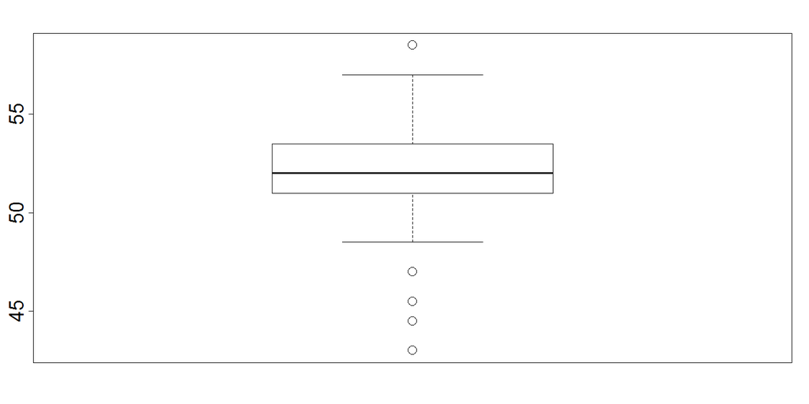

```r
boxplot(famil$ET0,cex.lab=3, cex.axis=3, cex.main=3, cex.sub=3,cex=3) # taille de l'enfant
```

### Visualisation Univariée quanti [hist]

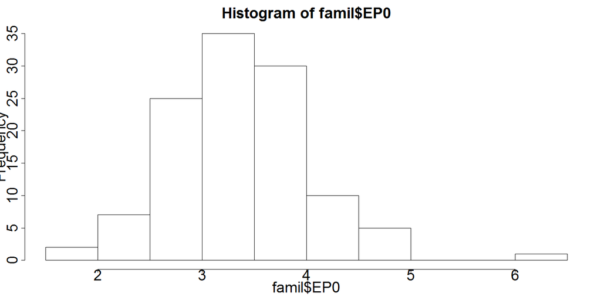

```r
hist(famil$EP0,cex.lab=3, cex.axis=3, cex.main=3, cex.sub=3,cex=3)# poids de l'enfant
```

### Visualisation Univariée quali [table & barplot]

Pour les variables qualitatives, on aura plutôt tendance à considérer les fréquences des modalités.

```r
table(famil$ESx)
```

```
 F  M
46 69
```

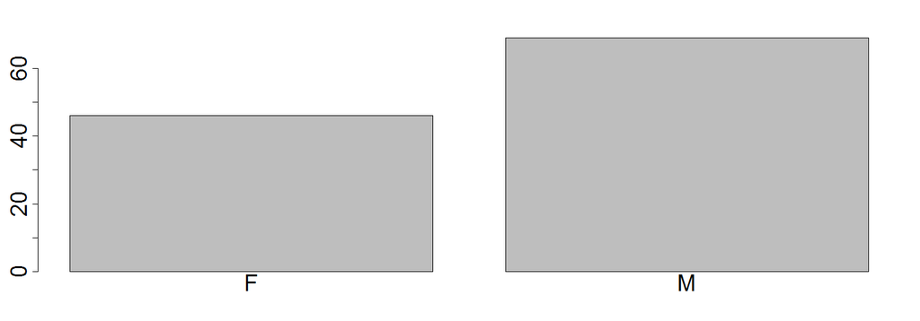

```r
barplot(table(famil$ESx),cex.lab=3, cex.axis=3, cex.main=3, cex.sub=3,cex=3) # sexe de l'enfant
```

Pour les variables qualitatives, on aura plutôt tendance à considérer les fréquences des modalités.

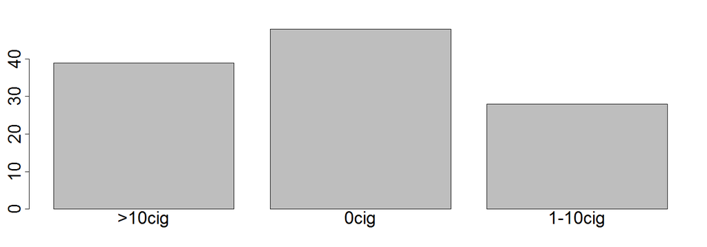

```r
barplot(table(famil$MCig0),cex.lab=3, cex.axis=3, cex.main=3, cex.sub=3,cex=3) # consommation de cigarettes
```

### Visualisation Univariée quali [pie]

Pour les variables qualitatives, on aura plutôt tendance à considérer les fréquences des modalités.

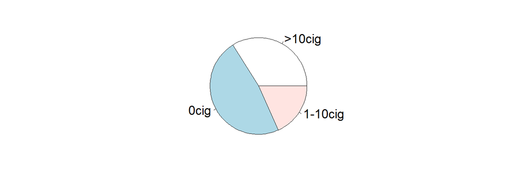

```r
pie(table(famil$MCig10),cex.lab=3, cex.axis=3, cex.main=3, cex.sub=3,cex=3) # consommation de cigarettes dix ans après
```

### Visualisation Bivariée quanti [pairs]

Pour analyser grossièrement les liaisons, on peut regarder un nuage de points

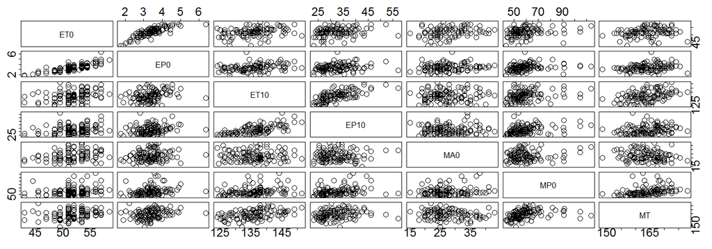

```r
pairs(famil[,c(3:6,8,9,11)],cex.lab=3, cex.axis=3, cex.main=3, cex.sub=3,cex=3)
```

### Visualisation Bivariée quanti [plot]

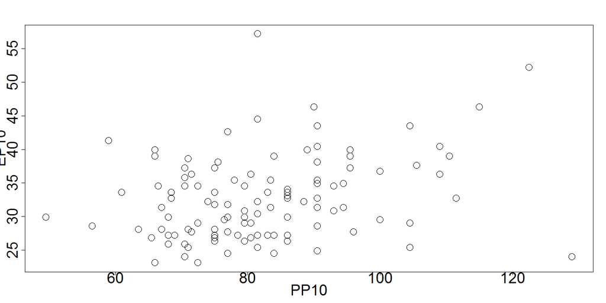

```r
plot(EP10~PP10,data=famil,cex.lab=3, cex.axis=3, cex.main=3, cex.sub=3,cex=3) # poids de l'enfant à 10 ans, poids du père
```

### Visualisation Bivariée quanti [plot & lm & abline]

On peut facilement ajouter la droite de regression

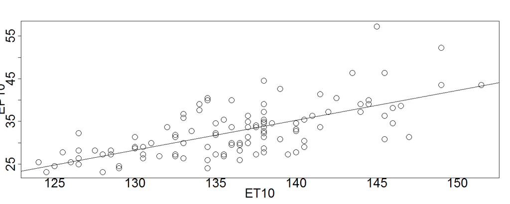

```r
plot(EP10~ET10,data=famil,cex.lab=3, cex.axis=3, cex.main=3, cex.sub=3,cex=3) # poids de l'enfant à 10 ans, taille à 10 ans
abline(lm(EP10 ~ ET10,data = famil),cex.lab=3, cex.axis=3, cex.main=3, cex.sub=3,cex=3)
```

### Analyse Bivariée quali [table & addmargins]

Pour analyser grossièrement les liaisons entre variables qualitatives, on aura recours aux tables de contingence

```r
table(famil$ESx,famil$ERh) # sexe et rhésus
```

```
    R- R+
  F  9 37
  M 13 56
```

```r
addmargins(table(famil$ESx,famil$ERh)) # avec les marges
```

```
       R-  R+ Sum
  F     9  37  46
  M    13  56  69
  Sum  22  93 115
```

### Visualisation Bivariée quali [mosaicplot]

Une manière de représenter graphiquement ces tables est d'utiliser une moisaique

```r
prop.table(table(famil$ESx,famil$ERh)) # fréquences relatives
```

```
            R-         R+
  F 0.07826087 0.32173913
  M 0.11304348 0.48695652
```

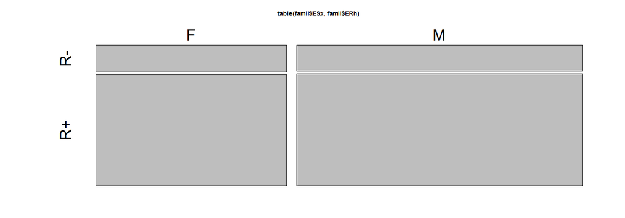

```r
mosaicplot(table(famil$ESx,famil$ERh),cex.lab=3, cex.axis=3, cex.main=3, cex.sub=3,cex=3)
```

### Visualisation Bivariée quali [mosaicplot]

```r
addmargins(table(famil$MCig0,famil$ESx)) # consommation de cigarette et sexe de l'enfant
```

```
            F   M Sum
  >10cig   11  28  39
  0cig     27  21  48
  1-10cig   8  20  28
  Sum      46  69 115
```

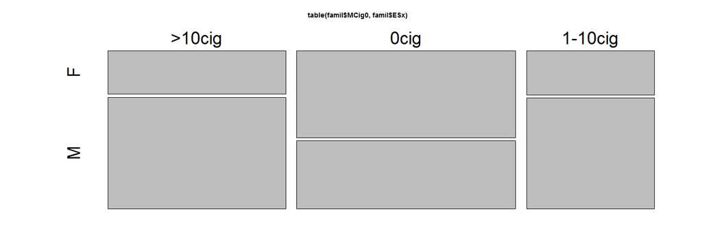

```r
mosaicplot(table(famil$MCig0,famil$ESx),cex.lab=3, cex.axis=3, cex.main=3, cex.sub=3,cex=3)
```

### Visualisation Bivariée quali x quanti [boxplot]

Si l'on veut croiser variables qualitatives et quantitatives, on peut utiliser les boites

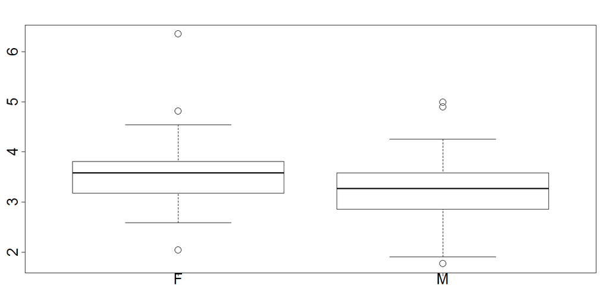

```r
boxplot(EP0~ESx,data=famil,cex.lab=3, cex.axis=3, cex.main=3, cex.sub=3,cex=3) # poids de l'enfant vs sexe
```

### Visualisation Bivariée quali x quanti [boxplot]

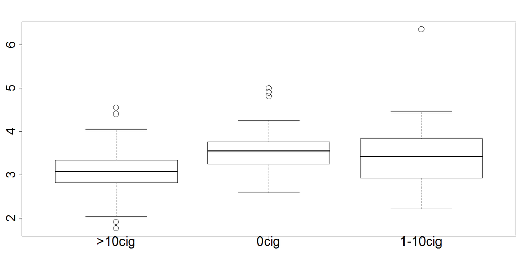

```r
boxplot(EP0~MCig0,data=famil,cex.lab=3, cex.axis=3, cex.main=3, cex.sub=3,cex=3) # poids de l'enfant vs consommation de cigarettes
```

### Manipulation des données - ordre des modalités

Remarque, les modalités de `Mcig0` ne sont pas dans l'ordre le plus naturel, on peut décider de réordonner les modalités.

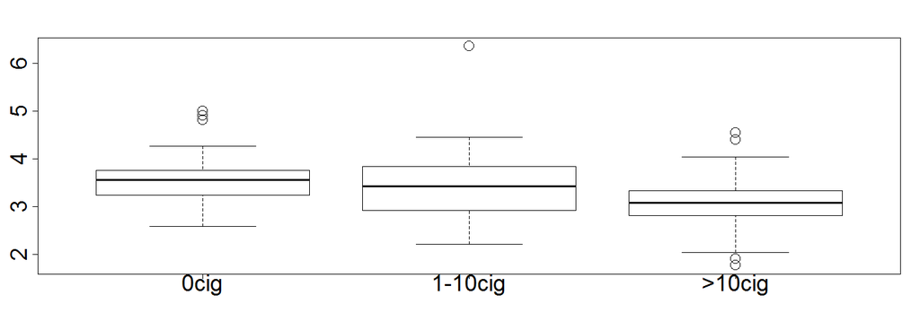

```r
famil$MCig0 <- factor(famil$MCig0, levels = c("0cig", "1-10cig", ">10cig"))

famil$MCig10 <- factor(famil$MCig10, levels = c("0cig", "1-10cig", ">10cig"))
boxplot(EP0~MCig0,data=famil,cex.lab=3, cex.axis=3, cex.main=3, cex.sub=3,cex=3) # poids de l'enfant vs consommation de cigarettes
```

### Test de liaison [chisq.test]

Quelques tests, imaginons qu'on veuille tester l'indépendance de deux variables qualitatives. Le test du \( \chi^2 \) sera adapté à ce problème (dans le cas où les effectifs d'une modalité sont trop faibles, il faut regrouper les modalités).

```r
chisq.test(table(famil$ESx,famil$ERh)) # Sexe de l'enfant vs Rhésus
```

```
    Pearson's Chi-squared test with Yates' continuity correction

data:  table(famil$ESx, famil$ERh)
X-squared = 5.6549e-31, df = 1, p-value = 1
```

```r
chisq.test(table(famil$ESx,famil$MCig0)) # Sexe de l'enfant vs consommation de cigarettes
```

```
    Pearson's Chi-squared test

data:  table(famil$ESx, famil$MCig0)
X-squared = 9.0657, df = 2, p-value = 0.01075
```

### Test de liaison [shapiro.test]

On s'intéresse à l'influence du sexe sur la taille à la naissance. Tester l'égalité des deux moyennes nécessite de vérifier préalablement plusieurs points : la normalité des distributions dans chaque classe à moins que l'échantillon soit considéré de taille suffisamment grande, le caractère indépendant ou appariés des échantillons, l'égalité ou non des variances à l'intérieur de chaque groupe. On dispose de deux échantillons indépendants : les garçons et les filles. Testons les autres hypothèses.

```r
# Normalité des distributions (facultatif car n grand ici)
shapiro.test(famil[famil$ESx=="M","ET0"])
```

```
    Shapiro-Wilk normality test

data:  famil[famil$ESx == "M", "ET0"]
W = 0.95676, p-value = 0.01779
```

```r
shapiro.test(famil[famil$ESx=="F","ET0"])
```

```
    Shapiro-Wilk normality test

data:  famil[famil$ESx == "F", "ET0"]
W = 0.95141, p-value = 0.05315
```

### Test de liaison [var.test]

On s'intéresse à l'influence du sexe sur la taille à la naissance. Tester l'égalité des deux moyennes nécessite de vérifier préalablement plusieurs points : la normalité des distributions dans chaque classe à moins que l'échantillon soit considéré de taille suffisamment grande, le caractère indépendant ou appariés des échantillons, l'égalité ou non des variances à l'intérieur de chaque groupe. On dispose de deux échantillons indépendants : les garçons et les filles. Testons les autres hypothèses.

```r
# égalité des variances (test de Fisher)
var.test(ET0~ESx,data=famil)
```

```
    F test to compare two variances

data:  ET0 by ESx
F = 0.92761, num df = 45, denom df = 68, p-value = 0.7979
alternative hypothesis: true ratio of variances is not equal to 1
95 percent confidence interval:
 0.5495201 1.6132113
sample estimates:
ratio of variances
         0.9276114
```

### Test de liaison [t.test]

Le test de comparaison des moyennes à utiliser (Student vs. Welsh) dépend du résultat précédent concernant l'égalité des variances.

```r
t.test(ET0~ESx,var.equal=F, data=famil) # si les variances sont différentes c'est un test de Welsh
```

```
    Welch Two Sample t-test

data:  ET0 by ESx
t = 2.9017, df = 99.064, p-value = 0.004573
alternative hypothesis: true difference in means is not equal to 0
95 percent confidence interval:
 0.5006535 2.6660131
sample estimates:
mean in group F mean in group M
       52.88043        51.29710
```

### Test de liaison [t.test]

Le test de comparaison des moyennes à utiliser (Student vs. Welsh) dépend du résultat précédent concernant l'égalité des variances.

```r
t.test(ET0~ESx,var.equal=T, data=famil) # Dans le cas où elles sont considérées égales, c'est un test de Student.
```

```
    Two Sample t-test

data:  ET0 by ESx
t = 2.8798, df = 113, p-value = 0.004761
alternative hypothesis: true difference in means is not equal to 0
95 percent confidence interval:
 0.4940799 2.6725868
sample estimates:
mean in group F mean in group M
       52.88043        51.29710
```

### Test de liaison [t.test]

Dans le cas d'échantillons appariés, par exemple si on se propose d'étudier l'évolution du poids de la mère au moment de la naissance et dix ans après, on utilise l'option `paired=TRUE`

```r
t.test(famil$MP0, famil$MP10,paired=TRUE)
```

```
    Paired t-test

data:  famil$MP0 and famil$MP10
t = -7.458, df = 114, p-value = 1.864e-11
alternative hypothesis: true difference in means is not equal to 0
95 percent confidence interval:
 -5.684285 -3.298324
sample estimates:
mean of the differences
              -4.491304
```

### Test de liaison - Remarques

- si l'hypothèse de normalité des distributions n'est pas vérifiée et si l'échantillon est trop réduit, c'est un test non-paramétrique qu'il faut mettre en ouvre. Les tests non-paramétriques sont basés sur les rangs des observations et donc sur les comparaisons des médianes des échantillons (wilcoxson).
- Si l'on veut tester l'indépendance entre une variable qualitative et quantitative, l'ANOVA associée à un test de Fisher est sans doute le test le plus utilisé ; il revient au test de Student lorsque la variable qualitative n'a que deux modalités.

### Régression linéaire - modèle [lm]

La régression simple permet de tester l'influence éventuelle d'une variable sur une autre et plus précisément, dans le cas de cet exemple, d'expliquer la taille de l'enfant à 10 ans. On estime le modèle avec la fonction `lm`

```r
res1.reg <- lm(ET10 ~ PT, data = famil)
names(res1.reg) # liste des résultats
```

```
 [1] "coefficients"  "residuals"     "effects"       "rank"
 [5] "fitted.values" "assign"        "qr"            "df.residual"
 [9] "xlevels"       "call"          "terms"         "model"
```

### Régression linéaire - Visualisation [qqnorm & qqline]

Les graphiques suivants permettent de s'assurer de la validité du modèle, et notamment de statuer sur l'homoscédasticité des résidus, leur normalité, la bonne linéarité du modèle.

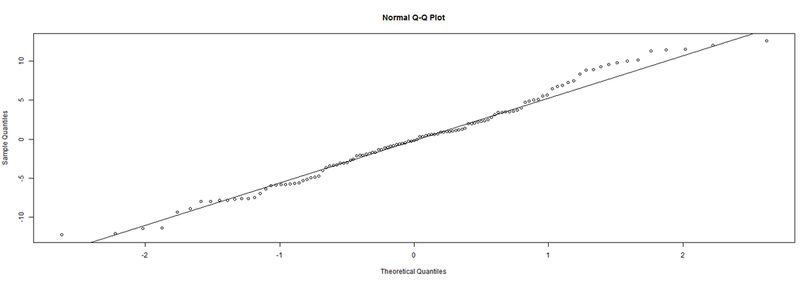

```r
qqnorm(res1.reg$residuals) # normalité des résidus
qqline(res1.reg$residuals)
```

### Régression linéaire [shapiro.test]

```r
shapiro.test(res1.reg$residuals)
```

```
    Shapiro-Wilk normality test

data:  res1.reg$residuals
W = 0.98511, p-value = 0.2346
```

### Régression linéaire [rstudent]

Les résidus sont “grands” si, une fois normalisés ou plutôt “studentisés”, ils sont de valeur absolue plus grande que 2.

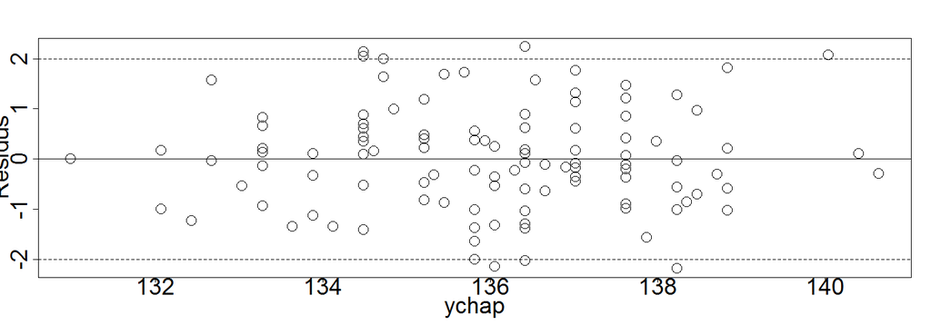

```r
res.student <- rstudent(res1.reg)
ychap=res1.reg$fitted.values
plot(res.student~ychap,ylab="Résidus",cex.lab=3, cex.axis=3, cex.main=3, cex.sub=3,cex=3)
abline(h=c(-2,0,2),lty=c(2,1,2)) # rajoute une ligne horizontale
```

### Régression linéaire [cook.distance]

Une observation est influente si elle a un grand résidu est est associée à une grande valeur sur la diagonale de la hat matrix. Cela correspond à une valeur élevée (plus grande que 1) de la distance de Cook.

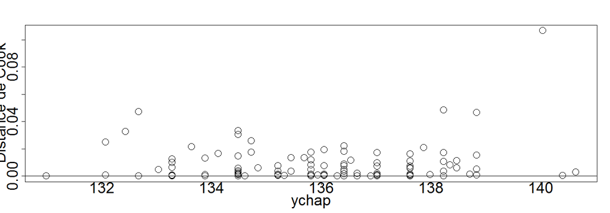

```r
cook <- cooks.distance(res1.reg) # repérage de points influents
plot(cook~ychap,ylab="Distance de Cook",cex.lab=3, cex.axis=3, cex.main=3, cex.sub=3,cex=3)
abline(h=c(0,1),lty=c(1,2))
```

### Régression linéaire - significativité [summary]

La significativité du modèle peut être analysée via la fonction `summary` :

```r
summary(res1.reg)
```

```
Call:
lm(formula = ET10 ~ PT, data = famil)

Residuals:
     Min       1Q   Median       3Q      Max
-12.2297  -3.8156  -0.1753   3.4956  12.5815

Coefficients:
            Estimate Std. Error t value Pr(>|t|)
(Intercept) 92.82881   12.44735   7.458 1.94e-11 ***
PT           0.24149    0.06949   3.475 0.000725 ***
---
Signif. codes:  0 '***' 0.001 '**' 0.01 '*' 0.05 '.' 0.1 ' ' 1

Residual standard error: 5.751 on 113 degrees of freedom
Multiple R-squared:  0.09657,   Adjusted R-squared:  0.08857
F-statistic: 12.08 on 1 and 113 DF,  p-value: 0.0007246
```

### Régression linéaire multivarié - significativité [plot]

La régression linéaire simple conduit à un modèle très mal ajusté. Le modèle linéaire multiple ci-dessous, plus complexe, recherche un meilleur ajustement des données.

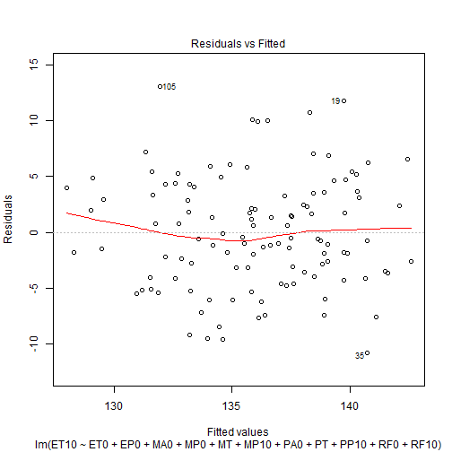

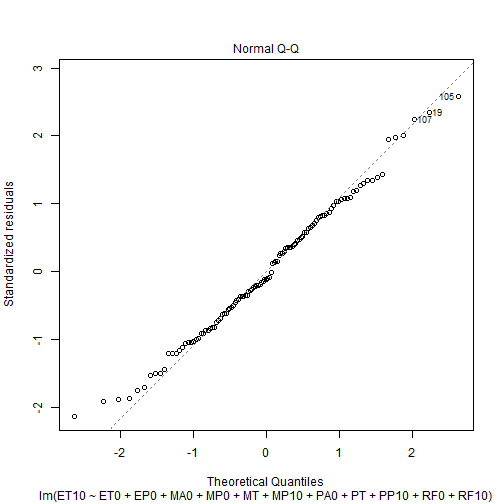

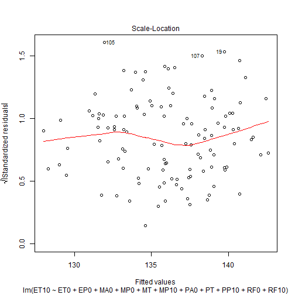

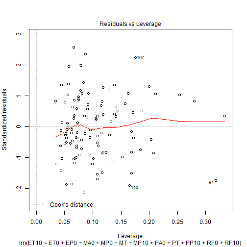

```r
res2.reg <- lm(ET10~ET0+EP0+MA0+MP0+MT+MP10+PA0+PT+PP10+RF0+RF10, data = famil)
plot(res2.reg) # diagnostics des résidus
```

### Régression linéaire multivarié - significativité [summary]

```r
summary(res2.reg) # résultats
```

```
Call:
lm(formula = ET10 ~ ET0 + EP0 + MA0 + MP0 + MT + MP10 + PA0 +
    PT + PP10 + RF0 + RF10, data = famil)

Residuals:
    Min      1Q  Median      3Q     Max
-10.753  -3.605  -0.583   3.575  13.055

Coefficients:
             Estimate Std. Error t value Pr(>|t|)
(Intercept) 19.395052  22.732841   0.853  0.39554
ET0          0.603298   0.293976   2.052  0.04269 *
EP0         -1.024211   1.330923  -0.770  0.44333
MA0         -0.070042   0.149033  -0.470  0.63937
MP0         -0.066802   0.082435  -0.810  0.41961
MT           0.346222   0.107974   3.207  0.00179 **
MP10         0.078521   0.079884   0.983  0.32794
PA0          0.147236   0.130401   1.129  0.26148
PT           0.154598   0.089309   1.731  0.08644 .
PP10         0.035471   0.050199   0.707  0.48140
RF0         -0.007751   0.016938  -0.458  0.64819
RF10        -0.010480   0.008614  -1.217  0.22652
---
Signif. codes:  0 '***' 0.001 '**' 0.01 '*' 0.05 '.' 0.1 ' ' 1

Residual standard error: 5.245 on 103 degrees of freedom
Multiple R-squared:  0.3152,    Adjusted R-squared:  0.242
F-statistic: 4.309 on 11 and 103 DF,  p-value: 2.792e-05
```